# Model Revision

## 2.2 Apply a Poission Generalized MM & check for overdispersion

```r
shrubs.B1 <- glmer(Buckthorn ~ Category * PC1 + Gap.Area.Site + (1 | Location), family = poisson, data = shrubs.EI)
E1 <- resid(shrubs.B1, type = "pearson")
N <- nrow(shrubs.EI)
p <- length(fixef(shrubs.B1)) + 1
sum(E1^2) / (N - p)
```

```
## [1] 14.59909
```

Yea, that’s way over 1 (super overdispersed)

## 2.3 Apply a negative binomial GLMM & check for overdispersion

```r
shrubs.B2 <- glmmTMB(Buckthorn ~ Category * PC1 + Gap.Area.Site + (1 | Location), family = "nbinom2", data = shrubs.EI)

E3 <- resid(shrubs.B2, type = "pearson")
N <- nrow(shrubs.EI)
p <- length(fixef(shrubs.B2)$cond) + 1 + 1
sum(E3^2) / (N - p)
```

```
## [1] 0.5120524
```

Now likely underdispersed, but better than before

### 2.3.1 Model Selection

Select ecological integrity (PC1 / PC2) with and without gap area

```r
#PC1 without gap area
shrubsfit.Ba <- glmmTMB(Buckthorn ~ Category * PC1 + (1 | Location), family = "nbinom2", data = shrubs.EI)
#PC1 with gap area
shrubsfit.Bb <- glmmTMB(Buckthorn ~ Category * PC1 + Gap.Area.Site + (1 | Location), family = "nbinom2", data = shrubs.EI)
#PC2 without gap area
shrubsfit.Bc <- glmmTMB(Buckthorn ~ Category * PC2 + (1 | Location), family = "nbinom2", data = shrubs.EI)
#PC2 with gap area
shrubsfit.Bd <- glmmTMB(Buckthorn ~ Category * PC2 + Gap.Area.Site + (1 | Location), family = "nbinom2", data = shrubs.EI)
#gap area in PCA
shrubsfit.Be <- glmmTMB(Buckthorn ~ Category * PC1b + (1 | Location), family = "nbinom2", data = shrubs.EI)
```

```r
AIC(shrubsfit.Ba, shrubsfit.Bb, shrubsfit.Bc, shrubsfit.Bd, shrubsfit.Be)
```

```
##              df      AIC
## shrubsfit.Ba  8 455.3764
## shrubsfit.Bb  9 453.7808
## shrubsfit.Bc  8 453.2132
## shrubsfit.Bd  9 455.1510
## shrubsfit.Be  8 458.7470
```

```r
shrubsfit.Bb <- glmmTMB(Buckthorn ~ Category * PC1 + Gap.Area.Site + (1 | Location), family = "nbinom2", data = shrubs.EI)
shrubsfit.Bb.no.inter <- glmmTMB(Buckthorn ~ Category + PC1 + Gap.Area.Site + (1 | Location), family = "nbinom2", data = shrubs.EI)
shrubsfit.null <- glmmTMB(Buckthorn ~ 1 + (1 | Location), family = "nbinom2", data = shrubs.EI)
anova(shrubsfit.Bb, shrubsfit.Bb.no.inter)
```

```
## Data: shrubs.EI
## Models:
## shrubsfit.Bb.no.inter: Buckthorn ~ Category + PC1 + Gap.Area.Site + (1 | Location), zi=~0, disp=~1
## shrubsfit.Bb: Buckthorn ~ Category * PC1 + Gap.Area.Site + (1 | Location), zi=~0, disp=~1
##                       Df    AIC    BIC  logLik deviance  Chisq Chi Df
## shrubsfit.Bb.no.inter  7 455.30 471.23 -220.65   441.30
## shrubsfit.Bb           9 453.78 474.27 -217.89   435.78 5.5155      2
##                       Pr(>Chisq)
## shrubsfit.Bb.no.inter
## shrubsfit.Bb             0.06344 .
## ---
## Signif. codes:  0 '***' 0.001 '**' 0.01 '*' 0.05 '.' 0.1 ' ' 1
```

```r
AIC(shrubsfit.Bb, shrubsfit.Bb.no.inter, shrubsfit.null)
```

```
##                       df      AIC
## shrubsfit.Bb           9 453.7808
## shrubsfit.Bb.no.inter  7 455.2962
## shrubsfit.null         3 463.8500
```

p-value for interaction is now 0.06 (still marginally significant)

```r
summary(shrubs.B2)
```

```
##  Family: nbinom2  ( log )
## Formula:          Buckthorn ~ Category * PC1 + Gap.Area.Site + (1 | Location)
## Data: shrubs.EI
##
##      AIC      BIC   logLik deviance df.resid
##    453.8    474.3   -217.9    435.8       63
##
## Random effects:
##
## Conditional model:
##  Groups   Name        Variance Std.Dev.
##  Location (Intercept) 1.08e-08 0.0001039
## Number of obs: 72, groups:  Location, 6
##
## Overdispersion parameter for nbinom2 family (): 0.34
##
## Conditional model:
##                       Estimate Std. Error z value Pr(>|z|)
## (Intercept)            9.07861    2.48643   3.651 0.000261 ***
## CategoryNon-Gap       -2.66823    0.58783  -4.539 5.65e-06 ***
## CategoryOther Gap     -0.56264    0.50306  -1.118 0.263385
## PC1                   -0.73065    0.28456  -2.568 0.010238 *
## Gap.Area.Site         -0.04269    0.01725  -2.474 0.013348 *
## CategoryNon-Gap:PC1   -0.49142    0.46269  -1.062 0.288202
## CategoryOther Gap:PC1  0.59645    0.35743   1.669 0.095178 .
## ---
## Signif. codes:  0 '***' 0.001 '**' 0.01 '*' 0.05 '.' 0.1 ' ' 1
```

Effect of gap area now significant

### 2.3.2 Model Validation

#### 2.3.2.1 Residuals vs fitted values X

There are two types of fitted values for a GLM - the “link” predictions are estimates of $\eta$ and the response predictions are estimates of $\mu$.

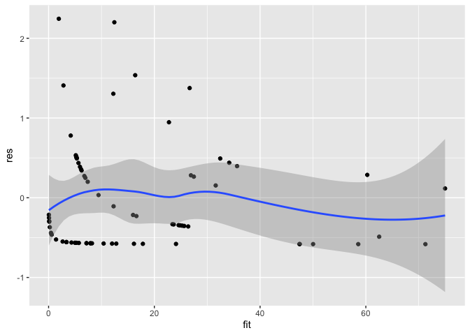

```r
shrubs.EI$res <- residuals(shrubsfit.Bb, type = "pearson")
shrubs.EI$fit <- predict(shrubsfit.Bb, type = "response")

ggplot(shrubs.EI,aes(x = fit, y = res)) +
  geom_point() + geom_smooth()
```

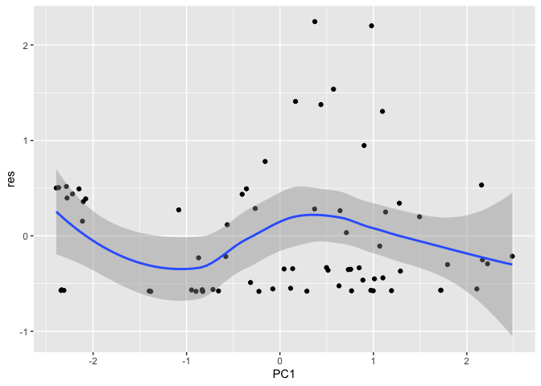

```r
ggplot(shrubs.EI, aes(x = PC1, y = res)) +
  geom_point() + geom_smooth()
```

#### 2.3.2.2 DHARMa Plots

```
## plotSimulatedResiduals is deprecated, please switch your code to simply using the plot() function
```

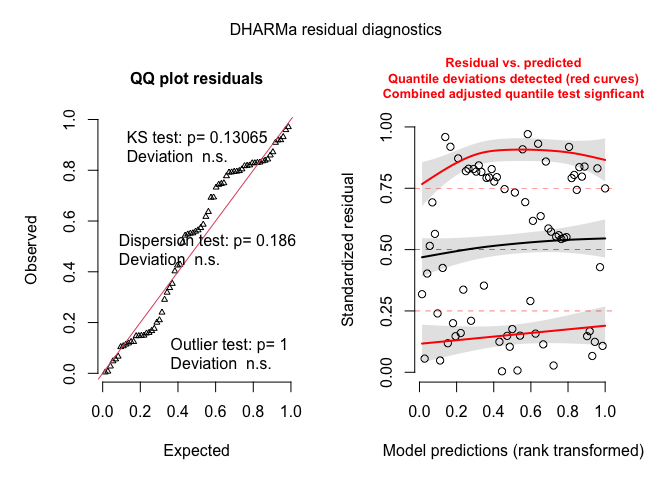

```r
simulationOutput1 <- simulateResiduals(fittedModel = shrubsfit.Bb, n = 1000)
plotSimulatedResiduals(simulationOutput = simulationOutput1)
```

```r
par(mfrow = c(1,3))
```

### 2.3.3 Test Gap Size

```r
names(gap.area) <- sub(" ", ".", names(gap.area)) #Replace spaces with .
gap.test <- lme(Gap.Area~Category,random=~1|Location,data=gap.area)
anova(gap.test)
```

```
##             numDF denDF  F-value p-value
## (Intercept)     1    41 96.89140  <.0001
## Category        1    41  1.28749  0.2631
```

```r
summary(gap.test)
```

```
## Linear mixed-effects model fit by REML
##  Data: gap.area
##        AIC      BIC    logLik
##   566.6578 573.9724 -279.3289
##
## Random effects:
##  Formula: ~1 | Location
##         (Intercept) Residual
## StdDev: 0.004330794 97.93859
##
## Fixed effects: Gap.Area ~ Category
##                      Value Std.Error DF   t-value p-value
## (Intercept)       155.1877  19.99163 41  7.762633  0.0000
## CategoryOther Gap -32.0801  28.27244 41 -1.134678  0.2631
##  Correlation:
##                   (Intr)
## CategoryOther Gap -0.707
##
## Standardized Within-Group Residuals:
##        Min         Q1        Med         Q3        Max
## -1.4588304 -0.6725202 -0.2158717  0.3635209  2.2730709
##
## Number of Observations: 48
## Number of Groups: 6
```

```r
gap.area %>% group_by(Category) %>% summarize(gap.area = mean(Gap.Area))
```

```
## # A tibble: 2 x 2
##   Category  gap.area
##   <chr>        <dbl>
## 1 EAB Gap       155.
## 2 Other Gap     123.
```

```r
intervals(gap.test,  which = "fixed")
```

```
## Approximate 95% confidence intervals
##
##  Fixed effects:
##                       lower     est.     upper
## (Intercept)       114.81378 155.1877 195.56161
## CategoryOther Gap -89.17744 -32.0801  25.01724
## attr(,"label")
## [1] "Fixed effects:"
```

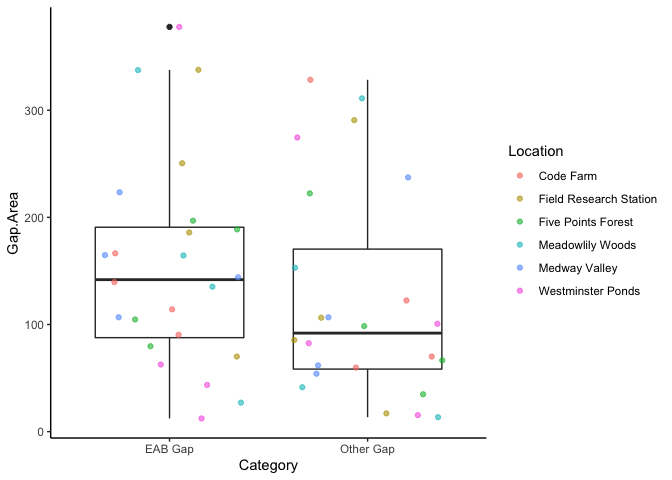

```r
ggplot(gap.area, aes(x = Category, y = Gap.Area)) +
  geom_boxplot() +
    geom_jitter(alpha=0.6, aes(col = Location)) +
  theme_classic()
```

### 2.3.4 Model Selection

```r
shrubs.0infl <- glmmTMB(Buckthorn ~ Category * PC1 + Gap.Area.Site + (1 | Location) + Management, ziformula = ~., family = "nbinom2", data = shrubs.EI)

shrubs.hurdle <- glmmTMB(Buckthorn ~ Category * PC1 + Gap.Area.Site + (1 | Location) + Management, ziformula = ~., family = "truncated_nbinom2", data = shrubs.EI)

#summary(shrubs.0infl)
#summary(shrubs.hurdle)
```

**Step 1: Compare to Negative Binomial**

```r
AIC(shrubs.0infl, shrubs.hurdle, shrubs.B2) # Better than neg binomial
```

```
##               df      AIC
## shrubs.0infl  19 427.5488
## shrubs.hurdle 19 427.6976
## shrubs.B2      9 453.7808
```

Both the zero-inflated and zero-altered model are better than the original negative binomial model

We’re going to use zero-altered because it’s safe to assume that if buckthorn was present, it was recorded

**Step 2: Fixed Effects**

```r
str(shrubs.EI)
```

```
## 'data.frame':    72 obs. of  20 variables:
##  $ Location            : chr  "Code Farm" "Code Farm" "Code Farm" "Code Farm" ...
##  $ Category            : Factor w/ 3 levels "EAB Gap","Non-Gap",..: 1 1 1 1 2 2 2 2 3 3 ...
##  $ ID                  : int  1 2 3 4 1 2 3 4 1 2 ...
##  $ richness            : int  2 3 2 3 3 2 3 2 3 1 ...
##  $ H                   : num  0.5 0.965 0.693 1.099 0.736 ...
##  $ percentNN           : num  0 0 0 0 12.5 ...
##  $ percentB            : num  0 0 0 0 12.5 ...
##  $ Buckthorn           : int  0 0 0 0 10 0 0 0 10 0 ...
##  $ Edge.Distance       : num  5.59 61.89 59.79 14.57 85.46 ...
##  $ Fragment.Size       : int  37 37 37 37 37 37 37 37 37 37 ...
##  $ Percent.Tree        : int  50 90 80 30 70 50 110 100 60 40 ...
##  $ Management          : chr  "Private" "Private" "Private" "Private" ...
##  $ Buckthorn_Management: int  0 0 0 0 0 0 0 0 0 0 ...
##  $ Shade.Tolerance.Site: num  4.42 4.42 4.42 4.42 4.42 ...
##  $ Gap.Area.Site       : num  136 136 136 136 136 ...
##  $ PC1                 : num  -1.383 -0.828 -0.826 -0.899 -1.083 ...
##  $ PC2                 : num  0.1294 -0.0277 0.2463 0.8533 -0.1041 ...
##  $ PC1.s               : num [1:72, 1] -1.026 -0.614 -0.613 -0.666 -0.803 ...
##   ..- attr(*, "scaled:center")= num -1.89e-16
##   ..- attr(*, "scaled:scale")= num 1.35
##  $ res                 : num  -0.582 -0.581 -0.581 -0.581 0.272 ...
##  $ fit                 : num  71.26 47.5 47.44 50.03 6.76 ...
```

```r
shrubs.hurdle <- glmmTMB(Buckthorn ~ Category * PC1 + Gap.Area.Site + Management + (1 | Location),
                        ziformula = ~ Category * PC1 + Gap.Area.Site + Management + (1 | Location), family = "truncated_nbinom2", data = shrubs.EI)
```

Drop Management

```r
#AIC
427.70-428.10 #management
```

```
## [1] -0.4
```

```r
429.85-427.70 #gap size
```

```
## [1] 2.15
```

**Step 3: Simplify Zero-Inflation**

```r
shrubs.hurdle1a <- glmmTMB(Buckthorn ~ Category * PC1 + Gap.Area.Site + (1 | Location),
                        ziformula = ~  Category + PC1 + Gap.Area.Site + (1 | Location), family = "truncated_nbinom2", data = shrubs.EI)

shrubs.hurdle1b <- glmmTMB(Buckthorn ~ Category * PC1 + Gap.Area.Site + (1 | Location),
                        ziformula = ~ Category * PC1  + (1 | Location), family = "truncated_nbinom2", data = shrubs.EI)


AIC(shrubs.hurdle, shrubs.hurdle1a, shrubs.hurdle1b)
```

```
##                 df      AIC
## shrubs.hurdle   19 427.6976
## shrubs.hurdle1a 15 424.8045
## shrubs.hurdle1b 16 425.9393
```

```r
# 1a - drop interaction

shrubs.hurdle2a <- glmmTMB(Buckthorn ~ Category * PC1 + Gap.Area.Site + (1 | Location),
                        ziformula = ~  PC1 + Category + Gap.Area.Site + (1 | Location), family = "truncated_nbinom2", data = shrubs.EI)

shrubs.hurdle2b <- glmmTMB(Buckthorn ~ Category * PC1 + Gap.Area.Site + (1 | Location),
                        ziformula = ~  Category + Gap.Area.Site +  (1 | Location), family = "truncated_nbinom2", data = shrubs.EI)

shrubs.hurdle2c <- glmmTMB(Buckthorn ~ Category * PC1 + Gap.Area.Site + (1 | Location),
                        ziformula = ~  Category + PC1 + (1 | Location), family = "truncated_nbinom2", data = shrubs.EI)

AIC(shrubs.hurdle1a, shrubs.hurdle2a, shrubs.hurdle2b, shrubs.hurdle2c)
```

```
##                 df      AIC
## shrubs.hurdle1a 15 424.8045
## shrubs.hurdle2a 15 424.8045
## shrubs.hurdle2b 14 423.8449
## shrubs.hurdle2c 14 423.5389
```

```r
## 2c - drop gap area

shrubs.hurdle3a <- glmmTMB(Buckthorn ~ Category * PC1 + Gap.Area.Site + (1 | Location),
                        ziformula = ~   PC1 +  (1 | Location), family = "truncated_nbinom2", data = shrubs.EI)

shrubs.hurdle3b <- glmmTMB(Buckthorn ~ Category * PC1 + Gap.Area.Site + (1 | Location),
                        ziformula = ~  Category  + (1 | Location), family = "truncated_nbinom2", data = shrubs.EI)


AIC(shrubs.hurdle2c, shrubs.hurdle3a, shrubs.hurdle3b)
```

```
##                 df      AIC
## shrubs.hurdle2c 14 423.5389
## shrubs.hurdle3a 12 428.2726
## shrubs.hurdle3b 13 422.0300
```

```r
# 3b - drop PC1

shrubs.hurdle4 <- glmmTMB(Buckthorn ~ Category * PC1 + Gap.Area.Site + (1 | Location),
                        ziformula = ~ 1 +  (1 | Location), family = "truncated_nbinom2", data = shrubs.EI)

AIC(shrubs.hurdle3b, shrubs.hurdle4)
```

```
##                 df      AIC
## shrubs.hurdle3b 13 422.0300
## shrubs.hurdle4  11 426.9292
```

```r
anova(shrubs.hurdle3b, shrubs.hurdle4)
```

```
## Data: shrubs.EI
## Models:
## shrubs.hurdle4: Buckthorn ~ Category * PC1 + Gap.Area.Site + (1 | Location), zi=~1 + (1 | Location), disp=~1
## shrubs.hurdle3b: Buckthorn ~ Category * PC1 + Gap.Area.Site + (1 | Location), zi=~Category + (1 | Location), disp=~1
##                 Df    AIC    BIC  logLik deviance  Chisq Chi Df Pr(>Chisq)
## shrubs.hurdle4  11 426.93 451.97 -202.47   404.93
## shrubs.hurdle3b 13 422.03 451.63 -198.01   396.03 8.8992      2    0.01168 *
## ---
## Signif. codes:  0 '***' 0.001 '**' 0.01 '*' 0.05 '.' 0.1 ' ' 1
```

```r
# Keep Category

drop1(shrubs.hurdle3b)
```

```
## Single term deletions
##
## Model:
## Buckthorn ~ Category * PC1 + Gap.Area.Site + (1 | Location)
##               Df    AIC
## <none>           422.03
## Gap.Area.Site  1 423.21
## Category:PC1   2 428.57
```

```r
#AIC Scores

#Gap Category
430.9292-426.0300
```

```
## [1] 4.8992
```

```r
#Ecological integrity
427.5389-426.0300
```

```
## [1] 1.5089
```

```r
#Gap size
428.8045-427.5389
```

```
## [1] 1.2656
```

```r
#EI*Category
429.9393-428.8045
```

```
## [1] 1.1348
```

**Step 4: Simplify Negative-Binomial**

```r
shrubs.hurdle5 <- glmmTMB(Buckthorn ~ Category * PC1 + (1 | Location),
                        ziformula = ~ Category +  (1 | Location), family = "truncated_nbinom2", data = shrubs.EI)

shrubs.hurdle5b <-  glmmTMB(Buckthorn ~ Category * PC1 + Gap.Area.Site + (1 | Location),
                        ziformula = ~ Category +  (1 | Location), family = "truncated_nbinom2", data = shrubs.EI)


shrubs.hurdle6 <- glmmTMB(Buckthorn ~ Category + PC1 + (1 | Location),
                        ziformula = ~ Category +  (1 | Location), family = "truncated_nbinom2", data = shrubs.EI)


drop1(shrubs.hurdle5b)
```

```
## Single term deletions
##
## Model:
## Buckthorn ~ Category * PC1 + Gap.Area.Site + (1 | Location)
##               Df    AIC
## <none>           422.03
## Gap.Area.Site  1 423.21
## Category:PC1   2 428.57
```

```r
drop1(shrubs.hurdle5)
```

```
## Single term deletions
##
## Model:
## Buckthorn ~ Category * PC1 + (1 | Location)
##              Df    AIC
## <none>          423.21
## Category:PC1  2 427.97
```

```r
AIC(shrubs.hurdle5, shrubs.hurdle6)
```

```
##                df      AIC
## shrubs.hurdle5 12 423.2072
## shrubs.hurdle6 10 427.9651
```

Gap area is marginal and can be dropped

```r
#AIC Scores

#PC1*Category
427.9651-423.2072
```

```
## [1] 4.7579
```

```r
#Gap area
423.21-422.03
```

```
## [1] 1.18
```

### 2.3.5 Model Validatation (through simulation)

```r
sim.m5 <- simulate(shrubs.hurdle5, nsim = 999) %>% t() %>% as.data.frame() %>%
  gather(observation, sim_value)

sim.m5$Location <- rep(shrubs.EI$Location, each = 999)
sim.m5$obs.num <- as.numeric(str_extract(sim.m5$observation, "[:digit:]+"))


str(sim.m5)
```

```
## 'data.frame':    71928 obs. of  4 variables:
##  $ observation: chr  "V1" "V1" "V1" "V1" ...
##  $ sim_value  : num  41 0 0 76 0 35 102 0 22 95 ...
##  $ Location   : chr  "Code Farm" "Code Farm" "Code Farm" "Code Farm" ...
##  $ obs.num    : num  1 1 1 1 1 1 1 1 1 1 ...
```

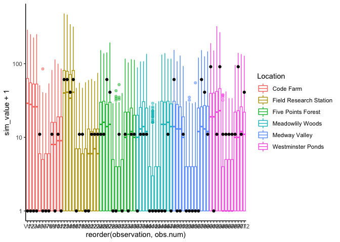

```r
ggplot() +
  geom_boxplot(data = sim.m5, aes(x = reorder(observation, obs.num),
                                  y = sim_value + 1,
                                  col = Location), alpha = 0.5) +
  scale_y_log10() +
  geom_point(data = shrubs.EI, aes(x = 1:72, y = Buckthorn + 1), col = "black") +
  theme_classic()
```

A lot of uncertainty but the real observations are usually in line the middle 50% of the simulations.

A bit more buckthorn than the model predicts at Westminster Ponds but I think that is consistent with previous knowledge.

### 2.3.6 Model validatation through simulation

```r
sim.m5 <- simulate(shrubs.hurdle5, nsim = 999) %>% t() %>% as.data.frame() %>%
  gather(observation, sim_value)

sim.m5$Location <- rep(shrubs.EI$Location, each = 999)
sim.m5$obs.num <- as.numeric(str_extract(sim.m5$observation, "[:digit:]+"))



str(sim.m5)
```

```
## 'data.frame':    71928 obs. of  4 variables:
##  $ observation: chr  "V1" "V1" "V1" "V1" ...
##  $ sim_value  : num  71 29 0 0 93 43 70 82 0 0 ...
##  $ Location   : chr  "Code Farm" "Code Farm" "Code Farm" "Code Farm" ...
##  $ obs.num    : num  1 1 1 1 1 1 1 1 1 1 ...
```

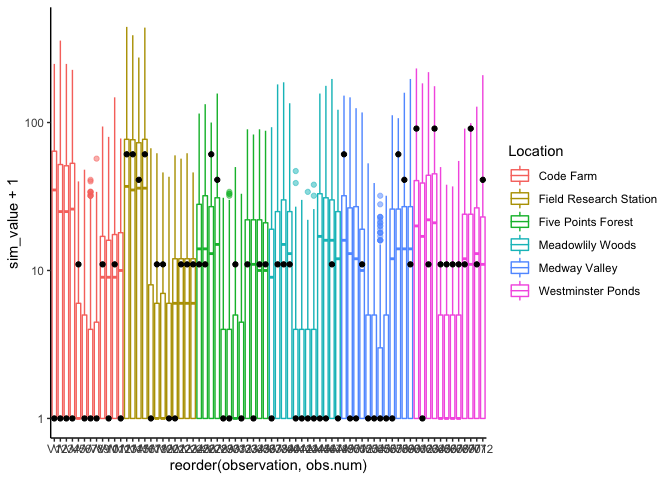

```r
ggplot() +
  geom_boxplot(data = sim.m5, aes(x = reorder(observation, obs.num),
                                  y = sim_value + 1,
                                  col = Location), alpha = 0.5) +
  scale_y_log10() +
  geom_point(data = shrubs.EI, aes(x = 1:72, y = Buckthorn + 1), col = "black") +
  theme_classic()
```

### 2.3.7 Plot Model Predictions

```r
non.min <- min(subset(shrubs.EI$PC1, shrubs.EI$Category == "Non-Gap"))
non.max<- max(subset(shrubs.EI$PC1, shrubs.EI$Category == "Non-Gap"))
EAB.min <- min(subset(shrubs.EI$PC1, shrubs.EI$Category == "EAB Gap"))
EAB.max <- max(subset(shrubs.EI$PC1, shrubs.EI$Category == "EAB Gap"))
other.min <- min(subset(shrubs.EI$PC1, shrubs.EI$Category == "Other Gap"))
other.max <- max(subset(shrubs.EI$PC1, shrubs.EI$Category == "Other Gap"))


pred <- data.frame(PC1 = c(seq(EAB.min, EAB.max, length.out = 100),
                               seq(other.min, other.max, length.out = 100),
                                   seq(non.min, non.max, length.out = 100)),
                   Category = c(rep("EAB Gap", 100), rep("Other Gap", 100), rep("Non-Gap", 100)),
                   Gap.Area.Site = rep(mean(shrubs.EI$Gap.Area.Site),300), # Added gap area
                   Management = c(rep("Private", 150), rep("Public", 150)),
                   Location = rep(NA, 300)) # This NA gives general predictions instead of location specific predictions

pred$fit <- predict(shrubs.hurdle5, newdata = pred, se.fit = TRUE, type = "link")$fit
pred$se <- predict(shrubs.hurdle5, newdata = pred, se.fit = TRUE, type = "link")$se.fit
str(pred)
```

```
## 'data.frame':    300 obs. of  7 variables:
##  $ PC1          : num  -2.28 -2.23 -2.19 -2.14 -2.1 ...
##  $ Category     : chr  "EAB Gap" "EAB Gap" "EAB Gap" "EAB Gap" ...
##  $ Gap.Area.Site: num  139 139 139 139 139 ...
##  $ Management   : chr  "Private" "Private" "Private" "Private" ...
##  $ Location     : logi  NA NA NA NA NA NA ...
##  $ fit          : num  4.29 4.27 4.26 4.24 4.23 ...
##  $ se           : num  0.404 0.398 0.392 0.386 0.38 ...
```

```r
pred.upr <- pred$fit + 1.96 * pred$se
pred.lwr <- pred$fit - 1.96 * pred$se

pred$upr <- ifelse(exp(pred.upr) < 100, exp(pred.upr), 100)
pred$lwr <- ifelse(exp(pred.lwr) > 0, exp(pred.lwr), 0)

pred$mean <- exp(pred$fit)
```

```r
mypalette2 = c(brewer.pal(12, "Paired")[c(12,2,4)])
str(pred)
```

```
## 'data.frame':    300 obs. of  10 variables:
##  $ PC1          : num  -2.28 -2.23 -2.19 -2.14 -2.1 ...
##  $ Category     : chr  "EAB Gap" "EAB Gap" "EAB Gap" "EAB Gap" ...
##  $ Gap.Area.Site: num  139 139 139 139 139 ...
##  $ Management   : chr  "Private" "Private" "Private" "Private" ...
##  $ Location     : logi  NA NA NA NA NA NA ...
##  $ fit          : num  4.29 4.27 4.26 4.24 4.23 ...
##  $ se           : num  0.404 0.398 0.392 0.386 0.38 ...
##  $ upr          : num  100 100 100 100 100 100 100 100 100 100 ...
##  $ lwr          : num  33 32.9 32.8 32.7 32.6 ...
##  $ mean         : num  72.9 71.8 70.8 69.7 68.6 ...
```

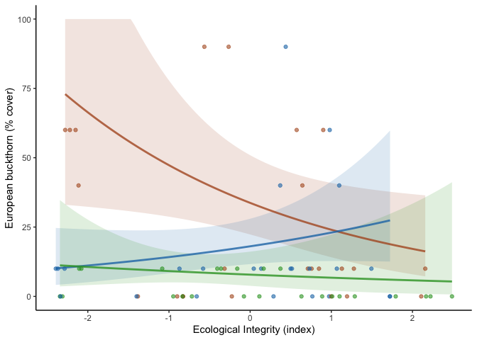

```r
shrubs.EI$Category = factor(shrubs.EI$Category, levels=c("EAB Gap", "Other Gap", "Non-Gap"))
pred$Category = factor(pred$Category, levels=c("EAB Gap", "Other Gap", "Non-Gap"))


fig.EI <- ggplot(pred, aes(x = PC1, y = mean)) +
    geom_ribbon(aes(x = PC1, ymin = lwr, ymax = upr, fill = Category), alpha = 0.15) +
      geom_point(data = shrubs.EI, aes(x = PC1, y = Buckthorn, col = Category), alpha = 0.6) +
  geom_line(aes(col = Category), size = 1, alpha = 0.8) +
  labs(x = "Ecological Integrity (index)",
       y = "European buckthorn (% cover)",
       col = "Category") +
  scale_y_continuous(limits = c(0, 100)) +
    scale_colour_manual(values = mypalette2) +
  scale_fill_manual(values = mypalette2) +
    theme_classic() +
 theme(legend.position = "none")

fig.EI
```

```r
#ggsave('fig.EI.jpeg',fig.EI , units = 'cm', width = 14, height = 10)
```

Check those high % buckthorn points - where are they coming from?

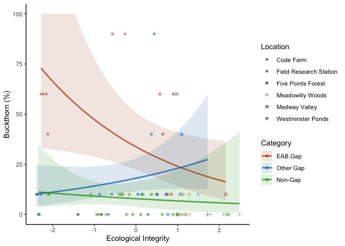

```r
ggplot(pred, aes(x = PC1, y = mean)) +
  geom_ribbon(aes(x = PC1, ymin = lwr, ymax = upr, fill = Category), alpha = 0.15) +
  geom_point(data = shrubs.EI, aes(x = PC1, y = Buckthorn, col = Category, shape = Location), alpha = 0.6) +
  geom_line(aes(col = Category), size = 1, alpha = 0.8) +
  labs(x = "Ecological Integrity",
       y = "Buckthorn (%)",
       col = "Category") +
  scale_colour_manual(values = mypalette2) +
  scale_fill_manual(values = mypalette2) +
  theme_classic()
```

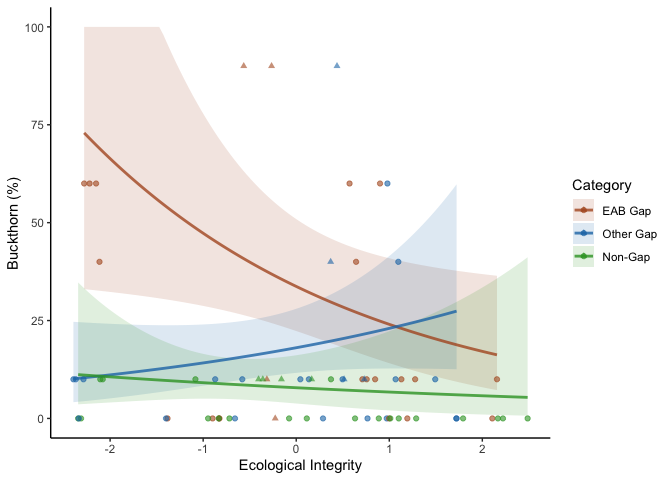

```r
# theme(legend.position = "none")

shrubs.EI.w <- shrubs.EI %>% filter(Location == "Westminster Ponds")
shrubs.EI.nw <- shrubs.EI %>% filter(Location != "Westminster Ponds")

ggplot(pred, aes(x = PC1, y = mean)) +
  geom_ribbon(aes(x = PC1, ymin = lwr, ymax = upr, fill = Category), alpha = 0.15) +
  geom_point(data = shrubs.EI.nw, aes(x = PC1, y = Buckthorn, col = Category), alpha = 0.6) +
  geom_point(data = shrubs.EI.w, aes(x = PC1, y = Buckthorn, col = Category), alpha = 0.6, shape = 17) +
  geom_line(aes(col = Category), size = 1, alpha = 0.8) +
  labs(x = "Ecological Integrity",
       y = "Buckthorn (%)",
       col = "Category") +
  scale_colour_manual(values = mypalette2) +
  scale_fill_manual(values = mypalette2) +
  theme_classic()
```

```r
# theme(legend.position = "none")
```

The 90% are all coming from Westminster Ponds

## 2.4 Model Summary

```r
summary(shrubs.hurdle5)
```

```
##  Family: truncated_nbinom2  ( log )
## Formula:          Buckthorn ~ Category * PC1 + (1 | Location)
## Zero inflation:             ~Category + (1 | Location)
## Data: shrubs.EI
##
##      AIC      BIC   logLik deviance df.resid
##    423.2    450.5   -199.6    399.2       60
##
## Random effects:
##
## Conditional model:
##  Groups   Name        Variance Std.Dev.
##  Location (Intercept) 0.103    0.3209
## Number of obs: 72, groups:  Location, 6
##
## Zero-inflation model:
##  Groups   Name        Variance Std.Dev.
##  Location (Intercept) 1.218    1.104
## Number of obs: 72, groups:  Location, 6
##
## Overdispersion parameter for truncated_nbinom2 family (): 2.93
##
## Conditional model:
##                       Estimate Std. Error z value Pr(>|z|)
## (Intercept)             3.5180     0.2103  16.728  < 2e-16 ***
## CategoryNon-Gap        -1.4585     0.3674  -3.970 7.19e-05 ***
## CategoryOther Gap      -0.6244     0.2338  -2.671  0.00756 **
## PC1                    -0.3386     0.1579  -2.145  0.03198 *
## CategoryNon-Gap:PC1     0.1869     0.3073   0.608  0.54301
## CategoryOther Gap:PC1   0.5806     0.1908   3.044  0.00234 **
## ---
## Signif. codes:  0 '***' 0.001 '**' 0.01 '*' 0.05 '.' 0.1 ' ' 1
##
## Zero-inflation model:
##                     Estimate Std. Error z value Pr(>|z|)
## (Intercept)       -8.883e-01  6.716e-01  -1.323   0.1859
## CategoryNon-Gap    1.751e+00  7.193e-01   2.435   0.0149 *
## CategoryOther Gap  3.277e-06  6.794e-01   0.000   1.0000
## ---
## Signif. codes:  0 '***' 0.001 '**' 0.01 '*' 0.05 '.' 0.1 ' ' 1
```

```r
exp(fixef(shrubs.hurdle5)$cond) # Intercept expected cover when present, others are multiplicative changes in cover conditional on presence
```

```
##           (Intercept)       CategoryNon-Gap     CategoryOther Gap
##            33.7154190             0.2325890             0.5355936
##                   PC1   CategoryNon-Gap:PC1 CategoryOther Gap:PC1
##             0.7128030             1.2055000             1.7871821
```

```r
exp(fixef(shrubs.hurdle5)$zi) # Intercept is odds of zero, others are odds ratios
```

```
##       (Intercept)   CategoryNon-Gap CategoryOther Gap
##         0.4113465         5.7618230         1.0000033
```

```r
exp(confint(shrubs.hurdle5))
```

```
##                                        2.5 %     97.5 %   Estimate
## cond.(Intercept)                  22.3264815 50.9139553 33.7154190
## cond.CategoryNon-Gap               0.1132062  0.4778683  0.2325890
## cond.CategoryOther Gap             0.3387368  0.8468538  0.5355936
## cond.PC1                           0.5231179  0.9712689  0.7128030
## cond.CategoryNon-Gap:PC1           0.6601346  2.2014151  1.2055000
## cond.CategoryOther Gap:PC1         1.2296463  2.5975110  1.7871821
## Location.cond.Std.Dev.(Intercept)  1.1056405  2.7882306  1.3783666
## zi.(Intercept)                     0.1102974  1.5340883  0.4113465
## zi.CategoryNon-Gap                 1.4069059 23.5968903  5.7618230
## zi.CategoryOther Gap               0.2640439  3.7872731  1.0000033
## Location.zi.Std.Dev.(Intercept)    1.5832860 14.1600376  3.0149229
```

I think I’ve figured out how to correctly interpret the odds ratios and intercept scores

```r
#Intercept
#Non-Gaps
33.715419*0.1132062 %>% round(2)#lower
```

```
## [1] 3.708696
```

```r
33.715419*0.2325890 %>% round(2) #estimate
```

```
## [1] 7.754546
```

```r
33.715419*0.4778683 %>% round(2)#upper
```

```
## [1] 16.1834
```

```r
#Other-Gaps
33.7154190*0.3387368 %>% round(2)#lower
```

```
## [1] 11.46324
```

```r
33.7154190*0.5355936 %>% round(2)#estimate
```

```
## [1] 18.20633
```

```r
33.7154190*0.8468538 %>% round(2)#upper
```

```
## [1] 28.65811
```

```r
#PC1
#Non-Gaps
0.7128030*0.6601346 %>% round(2)#lower
```

```
## [1] 0.47045
```

```r
0.7128030*1.2055000 %>% round(2)#estimate
```

```
## [1] 0.8624916
```

```r
0.7128030*2.2014151 %>% round(2)#upper
```

```
## [1] 1.568167
```

```r
#Other-Gaps
0.7128030*1.2296463 %>% round(2)#lower
```

```
## [1] 0.8767477
```

```r
0.7128030*1.7871821 %>% round(2)#estimate
```

```
## [1] 1.275917
```

```r
0.7128030*2.5975110 %>% round(2)#upper
```

```
## [1] 1.853288
```

### 2.4.1 emtrends

emtrends extracts the slopes which are expressed relative to EAB gaps - I then use exp to “unlink” the predictions.

These values are really just PC1 * (Category:PC1)

I think the levels in here get mixed up somehow because the other-gap and non-gap categories come out mixed up - I’m going to use the values from above but I know where they’re coming from onw.

```r
emtrends(shrubs.hurdle5, pairwise ~ Category, var = "PC1")
```

```
## $emtrends
##  Category  PC1.trend    SE df lower.CL upper.CL
##  EAB Gap      -0.339 0.158 60   -0.654  -0.0228
##  Other Gap    -0.152 0.310 60   -0.771   0.4681
##  Non-Gap       0.242 0.177 60   -0.111   0.5953
##
## Confidence level used: 0.95
##
## $contrasts
##  contrast            estimate    SE df t.ratio p.value
##  EAB Gap - Other Gap   -0.187 0.307 60 -0.608  0.8162
##  EAB Gap - Non-Gap     -0.581 0.191 60 -3.044  0.0096
##  Other Gap - Non-Gap   -0.394 0.303 60 -1.298  0.4017
##
## P value adjustment: tukey method for comparing a family of 3 estimates
```

```r
exp(-0.339) %>% round(3)
```

```
## [1] 0.712
```

```r
exp(-0.152) %>% round(3)
```

```
## [1] 0.859
```

```r
exp(0.242) %>% round(3)
```

```
## [1] 1.274
```

## 2.5 Summary Statistics (for table)

```r
str(shrubs.EI)
```

```
## 'data.frame':    72 obs. of  20 variables:
##  $ Location            : chr  "Code Farm" "Code Farm" "Code Farm" "Code Farm" ...
##  $ Category            : Factor w/ 3 levels "EAB Gap","Other Gap",..: 1 1 1 1 3 3 3 3 2 2 ...
##  $ ID                  : int  1 2 3 4 1 2 3 4 1 2 ...
##  $ richness            : int  2 3 2 3 3 2 3 2 3 1 ...
##  $ H                   : num  0.5 0.965 0.693 1.099 0.736 ...
##  $ percentNN           : num  0 0 0 0 12.5 ...
##  $ percentB            : num  0 0 0 0 12.5 ...
##  $ Buckthorn           : int  0 0 0 0 10 0 0 0 10 0 ...
##  $ Edge.Distance       : num  5.59 61.89 59.79 14.57 85.46 ...
##  $ Fragment.Size       : int  37 37 37 37 37 37 37 37 37 37 ...
##  $ Percent.Tree        : int  50 90 80 30 70 50 110 100 60 40 ...
##  $ Management          : chr  "Private" "Private" "Private" "Private" ...
##  $ Buckthorn_Management: int  0 0 0 0 0 0 0 0 0 0 ...
##  $ Shade.Tolerance.Site: num  4.42 4.42 4.42 4.42 4.42 ...
##  $ Gap.Area.Site       : num  136 136 136 136 136 ...
##  $ PC1                 : num  -1.383 -0.828 -0.826 -0.899 -1.083 ...
##  $ PC2                 : num  0.1294 -0.0277 0.2463 0.8533 -0.1041 ...
##  $ PC1.s               : num [1:72, 1] -1.026 -0.614 -0.613 -0.666 -0.803 ...
##   ..- attr(*, "scaled:center")= num -1.89e-16
##   ..- attr(*, "scaled:scale")= num 1.35
##  $ res                 : num  -0.582 -0.581 -0.581 -0.581 0.272 ...
##  $ fit                 : num  71.26 47.5 47.44 50.03 6.76 ...
```

```r
shrubs.summary <- shrubs.EI %>% select(Location, Category, ID, Buckthorn, Edge.Distance, Fragment.Size, Percent.Tree, Shade.Tolerance.Site, PC1) %>%
  group_by(Location, Category) %>%
  summarize(Buckthorn = mean(Buckthorn), Edge.Distance = mean(Edge.Distance), Fragment.Size = mean(Fragment.Size),
            Percent.Tree = mean(Percent.Tree), Shade.Tolerance.Site = mean(Shade.Tolerance.Site), PC1 = mean(PC1)) %>%
  mutate_if(is.numeric, round, digits = 1)
```

```
## `mutate_if()` ignored the following grouping variables:
## Column `Location`
```

```r
shrubs.summary
```

```
## # A tibble: 18 x 8
## # Groups:   Location [6]
##    Location Category Buckthorn Edge.Distance Fragment.Size Percent.Tree
##    <chr>    <fct>        <dbl>         <dbl>         <dbl>        <dbl>
##  1 Code Fa… EAB Gap        0            35.5            37         62.5
##  2 Code Fa… Other G…       5           102.             37         60
##  3 Code Fa… Non-Gap        2.5          75.9            37         82.5
##  4 Field R… EAB Gap       55            62              11         92.5
##  5 Field R… Other G…       7.5          60.3            11         42.5
##  6 Field R… Non-Gap        5            57.4            11         52.5
##  7 Five Po… EAB Gap       30           192.            174         82.5
##  8 Five Po… Other G…       7.5         187.            174         60
##  9 Five Po… Non-Gap        2.5         201.            174         60
## 10 Meadowl… EAB Gap        7.5         257.            324         62.5
## 11 Meadowl… Other G…       2.5         256.            324         85
## 12 Meadowl… Non-Gap        0           248             324         67.5
## 13 Medway … EAB Gap       17.5         110.            230        100
## 14 Medway … Other G…      27.5         195.            230         70
## 15 Medway … Non-Gap        0           136.            230         70
## 16 Westmin… EAB Gap       47.5          55.8           199        115
## 17 Westmin… Other G…      37.5          90.3           199        115
## 18 Westmin… Non-Gap       10            80.7           199        105
## # … with 2 more variables: Shade.Tolerance.Site <dbl>, PC1 <dbl>
```

```r
shrubs.summary$Location <- revalue(shrubs.summary$Location, c("Field Research Station"="Private 1"))
shrubs.summary$Location <- revalue(shrubs.summary$Location, c("Code Farm"="Private 2"))
shrubs.summary$Location <- revalue(shrubs.summary$Location, c("Westminster Ponds"="Public 1"))
shrubs.summary$Location <- revalue(shrubs.summary$Location, c("Five Points Forest"="Private 3"))
shrubs.summary$Location <- revalue(shrubs.summary$Location, c("Medway Valley"="Public 2"))
shrubs.summary$Location <- revalue(shrubs.summary$Location, c("Meadowlily Woods"="Public 3"))

#write.csv(shrubs.summary, file = "shrubs_summary.csv")
```

```r
gap.area.summary <- EI5 %>% #summarize gap area
  filter(Category != "Non-Gap") %>%
  group_by(Location, Category) %>%
  summarize(Gap.Area.Site = mean(Gap.Area) %>% round(1))

gap.area.summary$Location <- revalue(gap.area.summary$Location, c("Field Research Station"="Private 1"))
gap.area.summary$Location <- revalue(gap.area.summary$Location, c("Code Farm"="Private 2"))
gap.area.summary$Location <- revalue(gap.area.summary$Location, c("Westminster Ponds"="Public 1"))
gap.area.summary$Location <- revalue(gap.area.summary$Location, c("Five Points Forest"="Private 3"))
gap.area.summary$Location <- revalue(gap.area.summary$Location, c("Medway Valley"="Public 2"))
gap.area.summary$Location <- revalue(gap.area.summary$Location, c("Meadowlily Woods"="Public 3"))

#write.csv(gap.area.summary, file = "gaps_summary.csv")
```

## 2.6 Run Model Without Western FRS

As per reviewer comments - influence of this station

Remove FRS from data

```r
shrubs.EI.wo <- shrubs.EI %>% filter(Location != "Field Research Station") %>%
  select(Location, Category, ID, Buckthorn, Management, Gap.Area.Site, PC1)
str(shrubs.EI.wo)
```

```
## 'data.frame':    60 obs. of  7 variables:
##  $ Location     : chr  "Code Farm" "Code Farm" "Code Farm" "Code Farm" ...
##  $ Category     : Factor w/ 3 levels "EAB Gap","Other Gap",..: 1 1 1 1 3 3 3 3 2 2 ...
##  $ ID           : int  1 2 3 4 1 2 3 4 1 2 ...
##  $ Buckthorn    : int  0 0 0 0 10 0 0 0 10 0 ...
##  $ Management   : chr  "Private" "Private" "Private" "Private" ...
##  $ Gap.Area.Site: num  136 136 136 136 136 ...
##  $ PC1          : num  -1.383 -0.828 -0.826 -0.899 -1.083 ...
```

Run model without FRS data

```r
shrubs.hurdle5.wo <- glmmTMB(Buckthorn ~ Category * PC1 + (1 | Location),
                        ziformula = ~ Category +  (1 | Location), family = "truncated_nbinom2", data = shrubs.EI.wo)
```

### 2.6.1 Compare Model Outputs

```r
exp(fixef(shrubs.hurdle5)$cond) # Intercept expected cover when present, others are multiplicative changes in cover conditional on presence
```

```
##           (Intercept)       CategoryNon-Gap     CategoryOther Gap
##            33.7154190             0.2325890             0.5355936
##                   PC1   CategoryNon-Gap:PC1 CategoryOther Gap:PC1
##             0.7128030             1.2055000             1.7871821
```

```r
exp(fixef(shrubs.hurdle5.wo)$cond)
```

```
##           (Intercept)     CategoryOther Gap       CategoryNon-Gap
##            49.2315112             0.3845417             0.1975805
##                   PC1 CategoryOther Gap:PC1   CategoryNon-Gap:PC1
##             0.4407283             3.7069936             2.2689714
```

Remove FRS:

- Even more buckthorn in average EI EAB gaps
- Greater discrepancy between EAB gaps & non-gaps
- Slope of PC1 in EAB gaps increases

Therefore, greater EAB & EI effect when we remove FRS

```r
#Non-gaps
33.7154190 * 0.2325890
```

```
## [1] 7.841836
```

```r
49.2315112 * 0.1975805
```

```
## [1] 9.727187
```

```r
#Other gaps
33.7154190 * 0.5355936
```

```
## [1] 18.05776
```

```r
49.2315112 *  0.3845417
```

```
## [1] 18.93157
```

```r
exp(fixef(shrubs.hurdle5)$zi) # Intercept is odds of zero, others are odds ratios
```

```
##       (Intercept)   CategoryNon-Gap CategoryOther Gap
##         0.4113465         5.7618230         1.0000033
```

```r
exp(fixef(shrubs.hurdle5.wo)$zi) # Intercept is odds of zero, others are odds ratios
```

```
##       (Intercept) CategoryOther Gap   CategoryNon-Gap
##         0.5730672         0.7672057         4.9923899
```

Remove FRS:

```r
exp(confint(shrubs.hurdle5))
```

```
##                                        2.5 %     97.5 %   Estimate
## cond.(Intercept)                  22.3264815 50.9139553 33.7154190
## cond.CategoryNon-Gap               0.1132062  0.4778683  0.2325890
## cond.CategoryOther Gap             0.3387368  0.8468538  0.5355936
## cond.PC1                           0.5231179  0.9712689  0.7128030
## cond.CategoryNon-Gap:PC1           0.6601346  2.2014151  1.2055000
## cond.CategoryOther Gap:PC1         1.2296463  2.5975110  1.7871821
## Location.cond.Std.Dev.(Intercept)  1.1056405  2.7882306  1.3783666
## zi.(Intercept)                     0.1102974  1.5340883  0.4113465
## zi.CategoryNon-Gap                 1.4069059 23.5968903  5.7618230
## zi.CategoryOther Gap               0.2640439  3.7872731  1.0000033
## Location.zi.Std.Dev.(Intercept)    1.5832860 14.1600376  3.0149229
```

```r
exp(confint(shrubs.hurdle5.wo))
```

```
##                                         2.5 %     97.5 %   Estimate
## cond.(Intercept)                  28.52113323 84.9805538 49.2315112
## cond.CategoryOther Gap             0.18017215  0.8207279  0.3845417
## cond.CategoryNon-Gap               0.08133583  0.4799613  0.1975805
## cond.PC1                           0.24618336  0.7890112  0.4407283
## cond.CategoryOther Gap:PC1         1.45022580  9.4756291  3.7069936
## cond.CategoryNon-Gap:PC1           0.53113419  9.6929014  2.2689714
## Location.cond.Std.Dev.(Intercept)  1.00000000        Inf  1.0000605
## zi.(Intercept)                     0.13614110  2.4122474  0.5730672
## zi.CategoryOther Gap               0.18368121  3.2044900  0.7672057
## zi.CategoryNon-Gap                 1.06280095 23.4511994  4.9923899
## Location.zi.Std.Dev.(Intercept)    1.55107946 19.6450909  3.1370843
```

Remove FRS:

- In general, confidence intervals become wider (more uncertainty)

### 2.6.2 Visualize Model Predictions

```r
pred.wo <- data.frame(PC1 = c(seq(EAB.min, EAB.max, length.out = 100),
                               seq(other.min, other.max, length.out = 100),
                                   seq(non.min, non.max, length.out = 100)),
                   Category = c(rep("EAB Gap", 100), rep("Other Gap", 100), rep("Non-Gap", 100)),
                   Gap.Area.Site = rep(mean(shrubs.EI$Gap.Area.Site),300), # Added gap area
                   Management = c(rep("Private", 150), rep("Public", 150)),
                   Location = rep(NA, 300)) # This NA gives general predictions instead of location specific predictions

pred.wo$fit <- predict(shrubs.hurdle5.wo, newdata = pred, se.fit = TRUE, type = "link")$fit
pred.wo$se <- predict(shrubs.hurdle5.wo, newdata = pred, se.fit = TRUE, type = "link")$se.fit
str(pred.wo)
```

```
## 'data.frame':    300 obs. of  7 variables:
##  $ PC1          : num  -2.28 -2.23 -2.19 -2.14 -2.1 ...
##  $ Category     : chr  "EAB Gap" "EAB Gap" "EAB Gap" "EAB Gap" ...
##  $ Gap.Area.Site: num  139 139 139 139 139 ...
##  $ Management   : chr  "Private" "Private" "Private" "Private" ...
##  $ Location     : logi  NA NA NA NA NA NA ...
##  $ fit          : num  5.76 5.73 5.69 5.65 5.62 ...
##  $ se           : num  0.886 0.873 0.86 0.847 0.834 ...
```

```r
pred.upr <- pred.wo$fit + 1.96 * pred$se
pred.lwr <- pred.wo$fit - 1.96 * pred$se

pred.wo$upr <- ifelse(exp(pred.upr) < 100, exp(pred.upr), 100)
pred.wo$lwr <- ifelse(exp(pred.lwr) > 0, exp(pred.lwr), 0)

pred.wo$mean <- exp(pred.wo$fit)
```

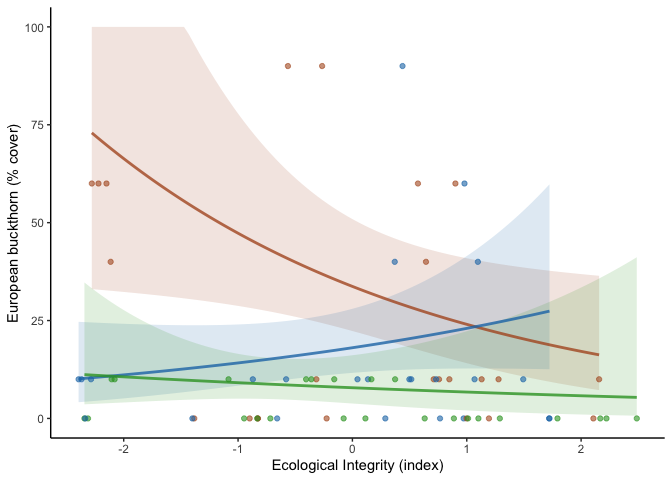

```r
shrubs.EI.wo$Category = factor(shrubs.EI.wo$Category, levels=c("EAB Gap", "Other Gap", "Non-Gap"))
pred.wo$Category = factor(pred.wo$Category, levels=c("EAB Gap", "Other Gap", "Non-Gap"))

fig.EI.wo <- ggplot(pred.wo, aes(x = PC1, y = mean)) +
    geom_ribbon(aes(x = PC1, ymin = lwr, ymax = upr, fill = Category), alpha = 0.15) +
      geom_point(data = shrubs.EI.wo, aes(x = PC1, y = Buckthorn, col = Category), alpha = 0.6) +
  geom_line(aes(col = Category), size = 1, alpha = 0.8) +
  labs(x = "Ecological Integrity",
       y = "Buckthorn (%)",
       col = "Category") +
  scale_y_continuous(limits = c(0, 100)) +
    scale_colour_manual(values = mypalette2) +
  scale_fill_manual(values = mypalette2) +
    theme_classic() +
 theme(legend.position = "none")

fig.EI
```

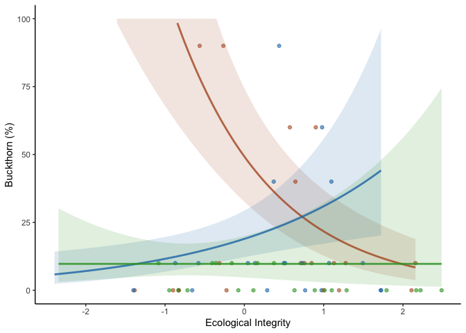

```r
fig.EI.wo
```

```r
#ggsave('fig.EI.noFRS.jpeg',fig.EI.wo , units = 'cm', width = 14, height = 10)
```

# 3 Reproducibility

```r
Sys.time()
```

```
## [1] "2020-05-22 12:28:04 PDT"
```

```r
git2r::repository()
```

```
## Local:    master /Users/JenBaron/Documents/UWO/UWO 4th Year/Publication/Analysis/EAB_Manuscript
## Head:     [e37b8e5] 2020-05-22: init
```